# Project: Investigation of the data of about 10,000 movies collected from The Movie Database (TMDb)

# This data set contains information about 10,000 movies collected from The Movie Database (TMDb)

## Questions

1. Which genres are most popular from year to year?
2. What is the ditribution of the quantitative variables?
3. What kinds of properties are associated with movies that have high revenues?
4. With which particular keywords and genres did movies generate higher popularity ratings, average votes, revenues and return on investment?
5. Which directors and actors are most successful on average with all their films according to movies' popularity, return on investment and average vote?
6. Does the budget of a movie really play a role in its profitability?

```python
import numpy as np
import pandas as pd
import matplotlib.pyplot as plt
import seaborn as sns
%matplotlib inline
```

### General Properties

```python
df = pd.read_csv('D://Ойбек/Nanodegree/Project2/tmdb-movies.csv')
df.head()
```

|  | id | imdb_id | popularity | budget | revenue | original_title | cast | homepage | director | tagline | ... | overview | runtime | genres | production_companies | release_date | vote_count | vote_average | release_year | budget_adj | revenue_adj |
| --- | --- | --- | --- | --- | --- | --- | --- | --- | --- | --- | --- | --- | --- | --- | --- | --- | --- | --- | --- | --- | --- |
| 0 | 135397 | tt0369610 | 32.985763 | 150000000 | 1513528810 | Jurassic World | Chris Pratt\|Bryce Dallas Howard\|Irrfan Khan\|Vi... | http://www.jurassicworld.com/ | Colin Trevorrow | The park is open. | ... | Twenty-two years after the events of Jurassic ... | 124 | Action\|Adventure\|Science Fiction\|Thriller | Universal Studios\|Amblin Entertainment\|Legenda... | 6/9/15 | 5562 | 6.5 | 2015 | 1.379999e+08 | 1.392446e+09 |
| 1 | 76341 | tt1392190 | 28.419936 | 150000000 | 378436354 | Mad Max: Fury Road | Tom Hardy\|Charlize Theron\|Hugh Keays-Byrne\|Nic... | http://www.madmaxmovie.com/ | George Miller | What a Lovely Day. | ... | An apocalyptic story set in the furthest reach... | 120 | Action\|Adventure\|Science Fiction\|Thriller | Village Roadshow Pictures\|Kennedy Miller Produ... | 5/13/15 | 6185 | 7.1 | 2015 | 1.379999e+08 | 3.481613e+08 |
| 2 | 262500 | tt2908446 | 13.112507 | 110000000 | 295238201 | Insurgent | Shailene Woodley\|Theo James\|Kate Winslet\|Ansel... | http://www.thedivergentseries.movie/#insurgent | Robert Schwentke | One Choice Can Destroy You | ... | Beatrice Prior must confront her inner demons ... | 119 | Adventure\|Science Fiction\|Thriller | Summit Entertainment\|Mandeville Films\|Red Wago... | 3/18/15 | 2480 | 6.3 | 2015 | 1.012000e+08 | 2.716190e+08 |
| 3 | 140607 | tt2488496 | 11.173104 | 200000000 | 2068178225 | Star Wars: The Force Awakens | Harrison Ford\|Mark Hamill\|Carrie Fisher\|Adam D... | http://www.starwars.com/films/star-wars-episod... | J.J. Abrams | Every generation has a story. | ... | Thirty years after defeating the Galactic Empi... | 136 | Action\|Adventure\|Science Fiction\|Fantasy | Lucasfilm\|Truenorth Productions\|Bad Robot | 12/15/15 | 5292 | 7.5 | 2015 | 1.839999e+08 | 1.902723e+09 |
| 4 | 168259 | tt2820852 | 9.335014 | 190000000 | 1506249360 | Furious 7 | Vin Diesel\|Paul Walker\|Jason Statham\|Michelle ... | http://www.furious7.com/ | James Wan | Vengeance Hits Home | ... | Deckard Shaw seeks revenge against Dominic Tor... | 137 | Action\|Crime\|Thriller | Universal Pictures\|Original Film\|Media Rights ... | 4/1/15 | 2947 | 7.3 | 2015 | 1.747999e+08 | 1.385749e+09 |

5 rows × 21 columns

```python
df.dtypes
```

```
id                        int64
imdb_id                  object
popularity              float64
budget                    int64
revenue                   int64
original_title           object
cast                     object
homepage                 object
director                 object
tagline                  object
keywords                 object
overview                 object
runtime                   int64
genres                   object
production_companies     object
release_date             object
vote_count                int64
vote_average            float64
release_year              int64
budget_adj              float64
revenue_adj             float64
dtype: object
```

As we see, data types are correct for the analysis. And let's check if there are any missing values

```python
df.isnull().sum()
```

```
id                         0
imdb_id                   10
popularity                 0
budget                     0
revenue                    0
original_title             0
cast                      76
homepage                7930
director                  44
tagline                 2824
keywords                1493
overview                   4
runtime                    0
genres                    23
production_companies    1030
release_date               0
vote_count                 0
vote_average               0
release_year               0
budget_adj                 0
revenue_adj                0
dtype: int64
```

As you see, some columns have missing values. But we can clean these according to our question and our need.

Furthermore, let's check for possible outliers. For this we can use .describe() function

```python
df.describe()
```

|  | id | popularity | budget | revenue | runtime | vote_count | vote_average | release_year | budget_adj | revenue_adj |
| --- | --- | --- | --- | --- | --- | --- | --- | --- | --- | --- |
| count | 10866.000000 | 10866.000000 | 1.086600e+04 | 1.086600e+04 | 10866.000000 | 10866.000000 | 10866.000000 | 10866.000000 | 1.086600e+04 | 1.086600e+04 |
| mean | 66064.177434 | 0.646441 | 1.462570e+07 | 3.982332e+07 | 102.070863 | 217.389748 | 5.974922 | 2001.322658 | 1.755104e+07 | 5.136436e+07 |
| std | 92130.136561 | 1.000185 | 3.091321e+07 | 1.170035e+08 | 31.381405 | 575.619058 | 0.935142 | 12.812941 | 3.430616e+07 | 1.446325e+08 |
| min | 5.000000 | 0.000065 | 0.000000e+00 | 0.000000e+00 | 0.000000 | 10.000000 | 1.500000 | 1960.000000 | 0.000000e+00 | 0.000000e+00 |
| 25% | 10596.250000 | 0.207583 | 0.000000e+00 | 0.000000e+00 | 90.000000 | 17.000000 | 5.400000 | 1995.000000 | 0.000000e+00 | 0.000000e+00 |
| 50% | 20669.000000 | 0.383856 | 0.000000e+00 | 0.000000e+00 | 99.000000 | 38.000000 | 6.000000 | 2006.000000 | 0.000000e+00 | 0.000000e+00 |
| 75% | 75610.000000 | 0.713817 | 1.500000e+07 | 2.400000e+07 | 111.000000 | 145.750000 | 6.600000 | 2011.000000 | 2.085325e+07 | 3.369710e+07 |
| max | 417859.000000 | 32.985763 | 4.250000e+08 | 2.781506e+09 | 900.000000 | 9767.000000 | 9.200000 | 2015.000000 | 4.250000e+08 | 2.827124e+09 |

It turns out that budget and revenue variables includes 0.0 values until 50% percentile. In order these 0.0 values not distort our budget-revenue-related analysis, we can remove corresponding rows when needed.

For the sake of simplicity, let's express dollar amounts "in millions" terms

```python
df[['budget', 'revenue', 'budget_adj', 'revenue_adj']] = (df[['budget', 'revenue', 'budget_adj', 'revenue_adj']] / 1000000)
df.rename(columns={'budget':'budget_mln', 'revenue':'revenue_mln', 'budget_adj':'budget_adj_mln', 'revenue_adj':'revenue_adj_mln'}, inplace=True)
```

```python
df.head(1)
```

|  | id | imdb_id | popularity | budget_mln | revenue_mln | original_title | cast | homepage | director | tagline | ... | overview | runtime | genres | production_companies | release_date | vote_count | vote_average | release_year | budget_adj_mln | revenue_adj_mln |
| --- | --- | --- | --- | --- | --- | --- | --- | --- | --- | --- | --- | --- | --- | --- | --- | --- | --- | --- | --- | --- | --- |
| 0 | 135397 | tt0369610 | 32.985763 | 150.0 | 1513.52881 | Jurassic World | Chris Pratt\|Bryce Dallas Howard\|Irrfan Khan\|Vi... | http://www.jurassicworld.com/ | Colin Trevorrow | The park is open. | ... | Twenty-two years after the events of Jurassic ... | 124 | Action\|Adventure\|Science Fiction\|Thriller | Universal Studios\|Amblin Entertainment\|Legenda... | 6/9/15 | 5562 | 6.5 | 2015 | 137.999939 | 1392.445893 |

1 rows × 21 columns

### Research Question 1 (Which genres are most popular from year to year?)

In our data the column 'genres' has some missing values. So we'll drop the rows with these missing values:

```python
df_genres = df.dropna(subset=['genres'])
df_genres.reset_index(drop=True, inplace=True)
df_genres['genres'].isnull().sum()
```

```
0
```

And the column 'genres' contain multiple values separated by pipe (|) characters. Let's fix this and create a new dataframe without (|) at least in the column 'genres'

```python
# 'genres' columns with (|):
genres_with_pipe = df_genres[df_genres['genres'].str.contains('|')]
genres_with_pipe.shape[0] == df_genres.shape[0]
```

```
True
```

If we know that how many pipes every cell in the "genres" column contains, we can split and create a new dataframe with replication (times number of pipes + 1) of every row with a single genre name in each

```python
df_genres['genres'].str.count('|')
```

```
0        42
1        42
2        35
3        41
4        22
         ..
10838    12
10839    23
10840    15
10841    14
10842     7
Name: genres, Length: 10843, dtype: int64
```

Oops, this is not what I want, so I will fix this like the following

```python
df_genres.loc[:,'genres'] = df_genres['genres'].str.replace("|", ";")
pipe_count = df_genres['genres'].str.count(';')
pipe_count
```

```
0        3
1        3
2        2
3        3
4        2
        ..
10838    0
10839    2
10840    1
10841    1
10842    0
Name: genres, Length: 10843, dtype: int64
```

And we will generate a new dataframe

```python
df_new = pd.concat([df_genres.iloc[0:1, :]]*((pipe_count+1)[0]), ignore_index=True)
df_new['genres'] = df_new.loc[0, 'genres'].split(';')
for n in range(1, df_genres.shape[0]):
    t = pd.concat([df_genres.iloc[n:(n+1), :]]*((pipe_count+1)[n]), ignore_index=True)
    t['genres'] = t.loc[0, 'genres'].split(';')
    df_new = df_new.append(t, ignore_index=True)
df_new
```

I took about 5 minutes for the above algorithm to finish. Sa I came up with a better solution:

```python
dfnew = pd.DataFrame(np.repeat(df_genres.values, list(pipe_count+1), axis=0))
dfnew.columns = df_genres.columns
dfnew['genres'] = list(np.concatenate(df_genres['genres'].str.split(';')))
dfnew.shape
```

```
(26960, 21)
```

Now our dataframe 'dfnew' is ready for the analysis for question 1.

So let's calculate the average popularity of every genre for each year:

```python
df_popularity = dfnew[['release_year', 'genres', 'popularity']]
df_popularity['popularity'] = df_popularity.loc[:, 'popularity'].apply(pd.to_numeric)
df_avg_popularity = df_popularity.groupby(['genres', 'release_year']).mean()
df_avg_popularity
```

| genres | release_year | popularity |
| --- | --- | --- |
| Action | 1960 | 0.590724 |
|  | 1961 | 0.365913 |
|  | 1962 | 0.708945 |
|  | 1963 | 0.951729 |
|  | 1964 | 0.813087 |
| ... | ... | ... |
| Western | 2011 | 1.175800 |
|  | 2012 | 1.732778 |
|  | 2013 | 0.665255 |
|  | 2014 | 0.673947 |
|  | 2015 | 3.178796 |

1049 rows × 1 columns

```python
df_avg_popularity2 = df_avg_popularity.reset_index(['release_year','genres'])
df_avg_popularity3 = df_avg_popularity2.loc[df_avg_popularity2.groupby("release_year")["popularity"].idxmax()]
```

```python
df_avg_popularity3
```

|  | genres | release_year | popularity |
| --- | --- | --- | --- |
| 890 | Thriller | 1960 | 0.811910 |
| 112 | Animation | 1961 | 2.631987 |
| 58 | Adventure | 1962 | 0.942513 |
| 113 | Animation | 1963 | 2.180410 |
| 949 | War | 1964 | 0.930959 |
| 636 | Music | 1965 | 0.968850 |
| 116 | Animation | 1966 | 0.585717 |
| 117 | Animation | 1967 | 1.348805 |
| 692 | Mystery | 1968 | 1.519456 |
| 229 | Crime | 1969 | 0.948020 |
| 120 | Animation | 1970 | 1.127718 |
| 385 | Family | 1971 | 1.530722 |
| 232 | Crime | 1972 | 1.072768 |
| 123 | Animation | 1973 | 0.956526 |
| 698 | Mystery | 1974 | 0.702035 |
| 71 | Adventure | 1975 | 0.880297 |
| 236 | Crime | 1976 | 0.707249 |
| 17 | Action | 1977 | 1.419319 |
| 648 | Music | 1978 | 0.679805 |
| 19 | Action | 1979 | 1.410014 |
| 816 | Science Fiction | 1980 | 0.897143 |
| 77 | Adventure | 1981 | 0.875815 |
| 965 | War | 1982 | 1.143183 |
| 79 | Adventure | 1983 | 0.900596 |
| 398 | Family | 1984 | 0.823924 |
| 399 | Family | 1985 | 0.924311 |
| 82 | Adventure | 1986 | 0.798935 |
| 547 | History | 1987 | 0.815643 |
| 28 | Action | 1988 | 0.599017 |
| 137 | Animation | 1989 | 1.177585 |
| 86 | Adventure | 1990 | 0.801768 |
| 139 | Animation | 1991 | 1.665002 |
| 140 | Animation | 1992 | 1.286893 |
| 461 | Fantasy | 1993 | 0.918601 |
| 254 | Crime | 1994 | 1.297888 |
| 143 | Animation | 1995 | 1.467780 |
| 256 | Crime | 1996 | 0.976838 |
| 833 | Science Fiction | 1997 | 1.140241 |
| 981 | War | 1998 | 1.246619 |
| 95 | Adventure | 1999 | 1.012306 |
| 96 | Adventure | 2000 | 0.854593 |
| 469 | Fantasy | 2001 | 1.565260 |
| 470 | Fantasy | 2002 | 1.430465 |
| 471 | Fantasy | 2003 | 1.747524 |
| 472 | Fantasy | 2004 | 1.320568 |
| 473 | Fantasy | 2005 | 1.117732 |
| 474 | Fantasy | 2006 | 1.023134 |
| 475 | Fantasy | 2007 | 0.957349 |
| 104 | Adventure | 2008 | 1.008385 |
| 105 | Adventure | 2009 | 1.138422 |
| 106 | Adventure | 2010 | 1.360319 |
| 1044 | Western | 2011 | 1.175800 |
| 1045 | Western | 2012 | 1.732778 |
| 109 | Adventure | 2013 | 1.260832 |
| 110 | Adventure | 2014 | 2.430526 |
| 111 | Adventure | 2015 | 3.283786 |

To see what genre has been most popular throughout the years, let's create bar chart:

```python
genres_popularity = df_avg_popularity3.groupby('genres').count()['release_year']
```

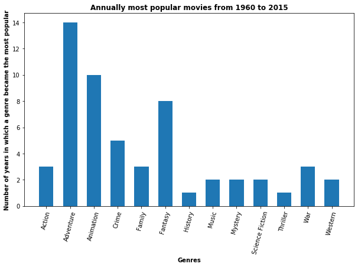

```python
x_labels = genres_popularity.index
y_labels = genres_popularity
plt.figure(figsize=(10, 6))
plt.bar(x_labels, y_labels, width=0.6)
plt.ylabel('Number of years in which a genre became the most popular', fontweight='bold')
plt.xlabel('Genres', fontweight='bold')
plt.xticks(range(len(x_labels)), x_labels, rotation=75)
plt.title('Annually most popular movies from 1960 to 2015', fontweight='bold')
```

So "adventure", "animation" and "fantasy" movies have been most popular throughout the years.

### Research Question 2 (What is the ditribution of the quantitative variables?)

The only variables that can be relevant in this question are the columns "popularity", "budget_mln", "revenue_mln", "runtime", "vote_average", "budget_adj_mln" and "revenue_adj_mln". So let's draw histograms for these parameters

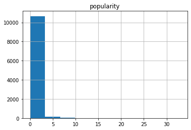

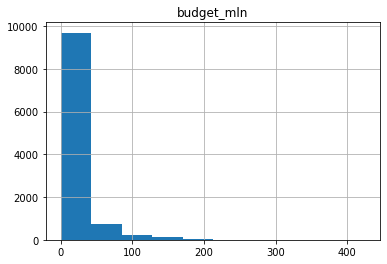

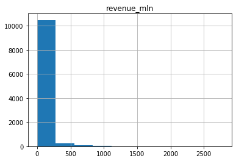

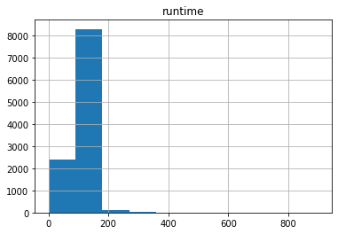

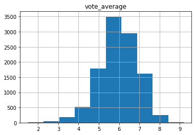

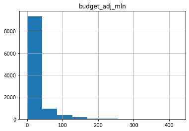

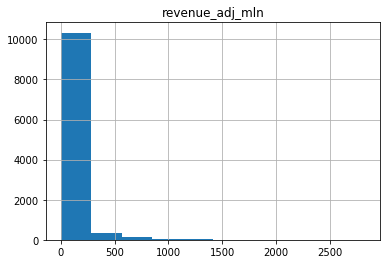

```python
qt_df= df[['popularity', 'budget_mln', 'revenue_mln', 'runtime', 'vote_average', 'budget_adj_mln', 'revenue_adj_mln']]
columns = qt_df.columns
columns
for n in columns:
    qt_df[[n]].hist()
```

### Research Question 3 (What kinds of properties are associated with movies that have high revenues?)

Let's divide the original dataframe into two dataframes that are above and below the average inflation-adjusted revenues, and we compare the average properties of both.

```python
df_above_mean_rev = df[df['revenue_adj_mln'] >= df.revenue_adj_mln.mean()]
df_below_mean_rev = df[df['revenue_adj_mln'] < df.revenue_adj_mln.mean()]
print(df_above_mean_rev.describe().loc['mean', :])
print(df_below_mean_rev.describe().loc['mean', :])
```

```
id                 31956.323751
popularity             1.557742
budget_mln            49.206124
revenue_mln          176.508220
runtime              113.056170
vote_count           772.407784
vote_average           6.306369
release_year        1999.214065
budget_adj_mln        58.304094
revenue_adj_mln      228.226088
Name: mean, dtype: float64
id                 75026.159675
popularity             0.406993
budget_mln             5.539549
revenue_mln            3.908786
runtime               99.184428
vote_count            71.556421
vote_average           5.887833
release_year        2001.876700
budget_adj_mln         6.843003
revenue_adj_mln        4.893200
Name: mean, dtype: float64
```

Resulting from this, we can see that movies that have higher revenues have higher budgets, popularity, average votes and runtime

### Research Question 4 (With which particular keywords and genres did movies generate higher popularity ratings, average votes, revenues and return on investment?)

#### For genres

For 'genres' let's return to the dataframe 'dfnew'. For popularity ratings there is no need to drop the outliers as we have seen from the disciption of the data that they are relatively scarce. So we will turn to 'dfnew' and create a bar chart for show average popularity of every genre. But first and foremost let's creat bar_chart function.

```python
def bar_chart(x,y, x_label, y_label, title):
    x_labels = x
    y_labels = y
    plt.figure(figsize=(12, 6))
    plt.bar(x_labels, y_labels, width=0.6)
    plt.ylabel(y_label, fontweight='bold')
    plt.xlabel(x_label, fontweight='bold')
    plt.xticks(range(len(x_labels)), x_labels, rotation=75)
    plt.title(title, fontweight='bold')
```

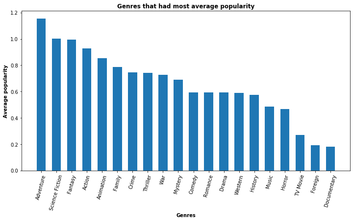

```python
dfnew[['popularity']] = dfnew.loc[:, ['popularity']].apply(pd.to_numeric)
x = dfnew[['genres', 'popularity']].groupby('genres').mean()['popularity'].sort_values(ascending=False).index
y = dfnew[['genres', 'popularity']].groupby('genres').mean()['popularity'].sort_values(ascending=False)
x_label = 'Genres'
y_label = 'Average popularity'
title = 'Genres that had most average popularity'
bar_chart(x,y, x_label, y_label, title)
```

"Adventure", "Science Fiction", "Fantasy" and "Action" are top 4 genres in terms of average popularity ratings of movies.

For vote_average there is no need to drop the outliers as we have seen from the disciption of the data that they are relatively scarce. So we will turn to 'dfnew' and create a bar chart for show average vote_average of every genre.

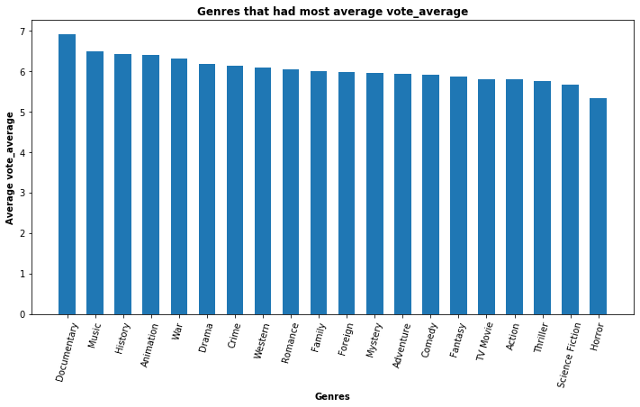

```python
dfnew[['vote_average']] = dfnew.loc[:, ['vote_average']].apply(pd.to_numeric)
x = dfnew[['genres', 'vote_average']].groupby('genres').mean()['vote_average'].sort_values(ascending=False).index
y = dfnew[['genres', 'vote_average']].groupby('genres').mean()['vote_average'].sort_values(ascending=False)
x_label = 'Genres'
y_label = 'Average vote_average'
title = 'Genres that had most average vote_average'
bar_chart(x,y, x_label, y_label, title)
```

"Documentary", "Music", "History" and "Animation" are top 4 genres in terms of average votes of movies.

For return on investment we should calculate (revenue_adj_mln - budget_adj_mln)/budget_adj_mln. If budget_adj_mln = 0, we receive an error message. So let's drop zero values in both 'budget_adj_mln' and 'revenue_adj_mln' in order to avoid distortion, and create 'return_on_inv' column

```python
dfnew_non_zero = dfnew[(dfnew['budget_adj_mln'] != 0) & (dfnew['revenue_adj_mln'] != 0)]
dfnew_non_zero['return_on_inv'] = (dfnew_non_zero['revenue_adj_mln'] - dfnew_non_zero['budget_adj_mln'])*100/dfnew_non_zero['budget_adj_mln']
dfnew_non_zero.head(1)
```

|  | id | imdb_id | popularity | budget_mln | revenue_mln | original_title | cast | homepage | director | tagline | ... | runtime | genres | production_companies | release_date | vote_count | vote_average | release_year | budget_adj_mln | revenue_adj_mln | return_on_inv |
| --- | --- | --- | --- | --- | --- | --- | --- | --- | --- | --- | --- | --- | --- | --- | --- | --- | --- | --- | --- | --- | --- |
| 0 | 135397 | tt0369610 | 32.985763 | 150 | 1513.53 | Jurassic World | Chris Pratt\|Bryce Dallas Howard\|Irrfan Khan\|Vi... | http://www.jurassicworld.com/ | Colin Trevorrow | The park is open. | ... | 124 | Action | Universal Studios\|Amblin Entertainment\|Legenda... | 6/9/15 | 5562 | 6.5 | 2015 | 138 | 1392.45 | 909.019 |

1 rows × 22 columns

And now we will calculate average revenue_adj_mln and return on investment for every genre.

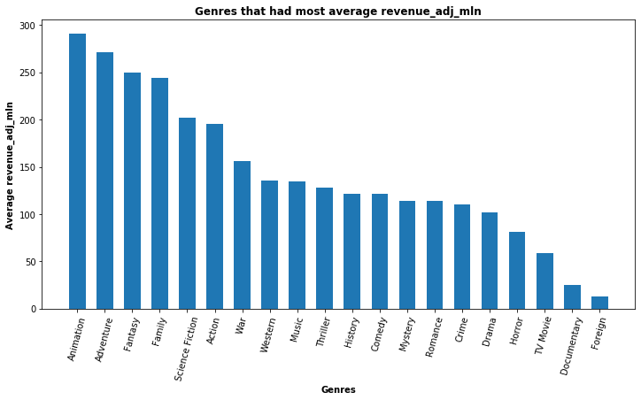

```python
dfnew_non_zero[['revenue_adj_mln']] = dfnew_non_zero.loc[:, ['revenue_adj_mln']].apply(pd.to_numeric)
x = dfnew_non_zero[['genres', 'revenue_adj_mln']].groupby('genres').mean()['revenue_adj_mln'].sort_values(ascending=False).index
y = dfnew_non_zero[['genres', 'revenue_adj_mln']].groupby('genres').mean()['revenue_adj_mln'].sort_values(ascending=False)
x_label = 'Genres'
y_label = 'Average revenue_adj_mln'
title = 'Genres that had most average revenue_adj_mln'
bar_chart(x,y, x_label, y_label, title)
```

"Animation", "Adventure", "Fantasy" and "Family" are top 4 genres in terms of average revenues (inflation adjusted) of movies.

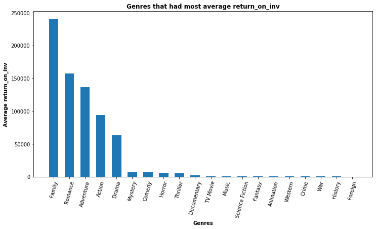

```python
dfnew_non_zero[['return_on_inv']] = dfnew_non_zero.loc[:, ['return_on_inv']].apply(pd.to_numeric)
x = dfnew_non_zero[['genres', 'return_on_inv']].groupby('genres').mean()['return_on_inv'].sort_values(ascending=False).index
y = dfnew_non_zero[['genres', 'return_on_inv']].groupby('genres').mean()['return_on_inv'].sort_values(ascending=False)
x_label = 'Genres'
y_label = 'Average return_on_inv'
title = 'Genres that had most average return_on_inv'
bar_chart(x,y, x_label, y_label, title)
```

"Family", "Romance", "Adventure" and "Action" are top 4 genres in terms of average ROI (return on investment) of movies.

#### For keywords

For keywords we will create a new df without pips.

```python
df_keywords = df.dropna(subset=['keywords'])
df_keywords.reset_index(drop=True, inplace=True)
df_keywords.loc[:,'keywords'] = df_keywords['keywords'].str.replace("|", ";")
pipe_count_keywords = df_keywords['keywords'].str.count(';')
dfnew_keywords = pd.DataFrame(np.repeat(df_keywords.values, list(pipe_count_keywords+1), axis=0))
dfnew_keywords.columns = df_keywords.columns
dfnew_keywords['keywords'] = list(np.concatenate(df_keywords['keywords'].str.split(';')))
```

And now we can calculate everage parametres for every keyword. In popularity and vote_average parameters there are not significant outliers.

Here is the average popularity for top 10 keywords

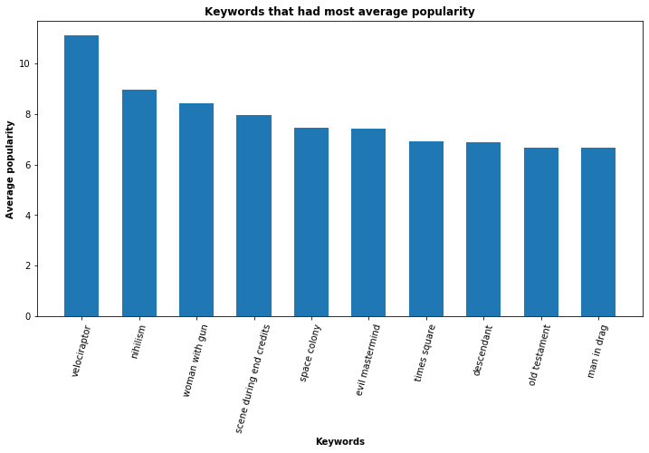

```python
dfnew_keywords[['popularity']] = dfnew_keywords.loc[:, ['popularity']].apply(pd.to_numeric)
x = dfnew_keywords[['keywords', 'popularity']].groupby('keywords').mean()['popularity'].sort_values(ascending=False).index[:10]
y = dfnew_keywords[['keywords', 'popularity']].groupby('keywords').mean()['popularity'].sort_values(ascending=False)[:10]
x_label = 'Keywords'
y_label = 'Average popularity'
title = 'Keywords that had most average popularity'
bar_chart(x, y, x_label, y_label, title)
```

"velociraptor", "nihilism", "woman with gun" and "scene during end credits" are top 4 keywords of films in terms of their average popularity.

Here is the average vote_average for top 10 keywords

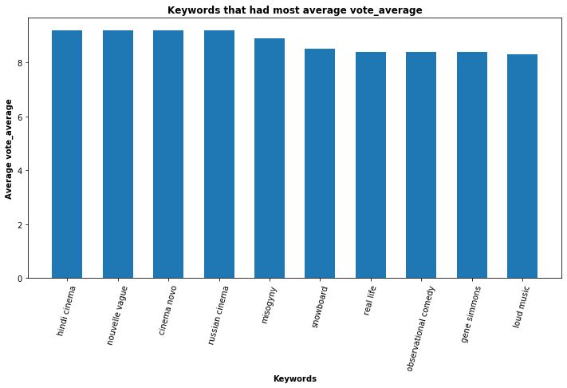

```python
dfnew_keywords[['vote_average']] = dfnew_keywords.loc[:, ['vote_average']].apply(pd.to_numeric)
x = dfnew_keywords[['keywords', 'vote_average']].groupby('keywords').mean()['vote_average'].sort_values(ascending=False).index[:10]
y = dfnew_keywords[['keywords', 'vote_average']].groupby('keywords').mean()['vote_average'].sort_values(ascending=False)[:10]
x_label = 'Keywords'
y_label = 'Average vote_average'
title = 'Keywords that had most average vote_average'
bar_chart(x, y, x_label, y_label, title)
```

"hindi cinema", "nouvelle vague", "cinema nove" and "russian cinema" are top 4 keywords in terms of movies' vote_average.

For return on investment we should calculate (revenue_adj_mln - budget_adj_mln)/budget_adj_mln. If budget_adj_mln = 0, we receive an error message. So let's drop zero values in both 'budget_adj_mln' and 'revenue_adj_mln' in order to avoid distortion, and create 'return_on_inv' column

```python
dfnew_keywords_non_zero = dfnew_keywords[(dfnew_keywords['budget_adj_mln'] != 0) & (dfnew_keywords['revenue_adj_mln'] != 0)]
dfnew_keywords_non_zero['return_on_inv'] = (dfnew_keywords_non_zero['revenue_adj_mln'] - dfnew_keywords_non_zero['budget_adj_mln'])*100/dfnew_keywords_non_zero['budget_adj_mln']
```

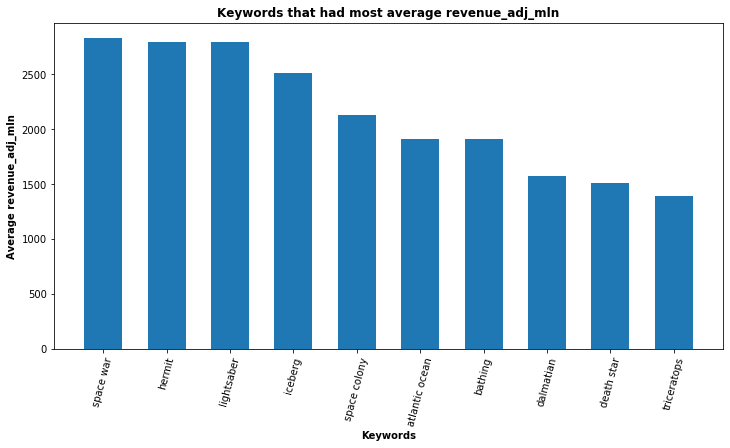

```python
dfnew_keywords_non_zero[['revenue_adj_mln']] = dfnew_keywords_non_zero.loc[:, ['revenue_adj_mln']].apply(pd.to_numeric)
x = dfnew_keywords_non_zero[['keywords', 'revenue_adj_mln']].groupby('keywords').mean()['revenue_adj_mln'].sort_values(ascending=False).index[:10]
y = dfnew_keywords_non_zero[['keywords', 'revenue_adj_mln']].groupby('keywords').mean()['revenue_adj_mln'].sort_values(ascending=False)[:10]
x_label = 'Keywords'
y_label = 'Average revenue_adj_mln'
title = 'Keywords that had most average revenue_adj_mln'
bar_chart(x, y, x_label, y_label, title)
```

"space war", "hermit", "lightsaber" and "iceberg" are top 4 keywords in terms of average revenues of films.

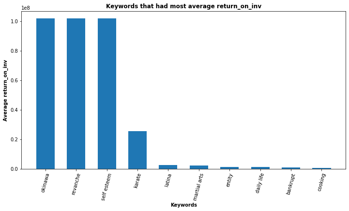

```python
dfnew_keywords_non_zero[['return_on_inv']] = dfnew_keywords_non_zero.loc[:, ['return_on_inv']].apply(pd.to_numeric)
x = dfnew_keywords_non_zero[['keywords', 'return_on_inv']].groupby('keywords').mean()['return_on_inv'].sort_values(ascending=False).index[:10]
y = dfnew_keywords_non_zero[['keywords', 'return_on_inv']].groupby('keywords').mean()['return_on_inv'].sort_values(ascending=False)[:10]
x_label = 'Keywords'
y_label = 'Average return_on_inv'
title = 'Keywords that had most average return_on_inv'
bar_chart(x, y, x_label, y_label, title)
```

"okinawa", "revanche" and "self esteem" and "karate" are top vivid keywords in terms of movies' average return on investment.

### Research Question 5 (Which directors and actors are most successful on average with all their films according to movies' popularity, return on investment and average vote?)

#### For directors

For film directors, let's create a dataframe without nulls and pipes:

```python
df_director = df.dropna(subset=['director'])
df_director.reset_index(drop=True, inplace=True)
df_director.loc[:,'director'] = df_director['director'].str.replace("|", ";")
pipe_count_dr = df_director['director'].str.count(';')
df_director2 = pd.DataFrame(np.repeat(df_director.values, list(pipe_count_dr+1), axis=0))
df_director2.columns = df_director.columns
df_director2['director'] = list(np.concatenate(df_director['director'].str.split(';')))
df_director2.shape
```

```
(11892, 21)
```

Outliers of pupularity and vote_average are not significant, so there is no need for dropping them. And for each director we will calculate average values of these parametres:

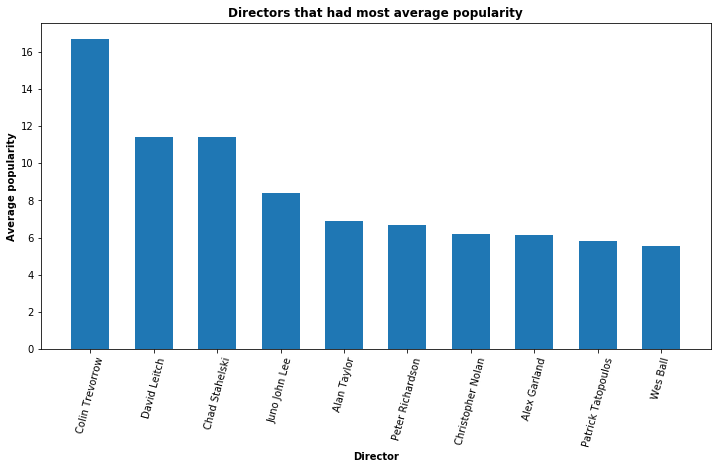

```python
df_director2[['popularity']] = df_director2.loc[:, ['popularity']].apply(pd.to_numeric)
x = df_director2[['director', 'popularity']].groupby('director').mean()['popularity'].sort_values(ascending=False).index[:10]
y = df_director2[['director', 'popularity']].groupby('director').mean()['popularity'].sort_values(ascending=False)[:10]
x_label = 'Director'
y_label = 'Average popularity'
title = 'Directors that had most average popularity'
bar_chart(x, y, x_label, y_label, title)
```

Colin Trevorrow, David Leitch, Chad Stahelski and are top 3 successful film directors in terms of average popularity of their movies.

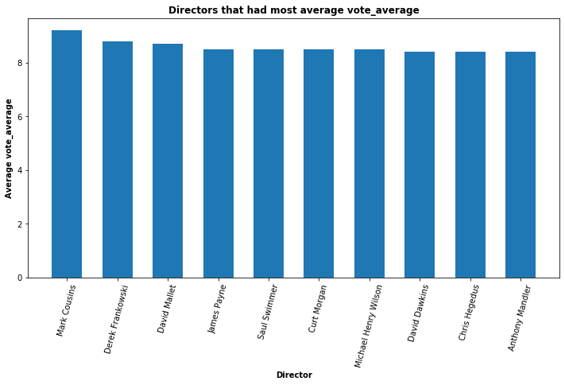

```python
df_director2[['vote_average']] = df_director2.loc[:, ['vote_average']].apply(pd.to_numeric)
x = df_director2[['director', 'vote_average']].groupby('director').mean()['vote_average'].sort_values(ascending=False).index[:10]
y = df_director2[['director', 'vote_average']].groupby('director').mean()['vote_average'].sort_values(ascending=False)[:10]
x_label = 'Director'
y_label = 'Average vote_average'
title = 'Directors that had most average vote_average'
bar_chart(x, y, x_label, y_label, title)
```

All the top 10 directors with highest vote_average had almost the same vote_average with each other, except for Mark Cousins having slightly more.

For return on investment we should calculate (revenue_adj_mln - budget_adj_mln)/budget_adj_mln. If budget_adj_mln = 0, we receive an error message. So let's drop zero values in both 'budget_adj_mln' and 'revenue_adj_mln' in order to avoid distortion, and create 'return_on_inv' column

```python
df_director_non_zero = df_director2[(df_director2['budget_adj_mln'] != 0) & (df_director2['revenue_adj_mln'] != 0)]
df_director_non_zero['return_on_inv'] = (df_director_non_zero['revenue_adj_mln'] - df_director_non_zero['budget_adj_mln'])*100/df_director_non_zero['budget_adj_mln']
```

And now we will calculate average revenue_adj_mln for every director.

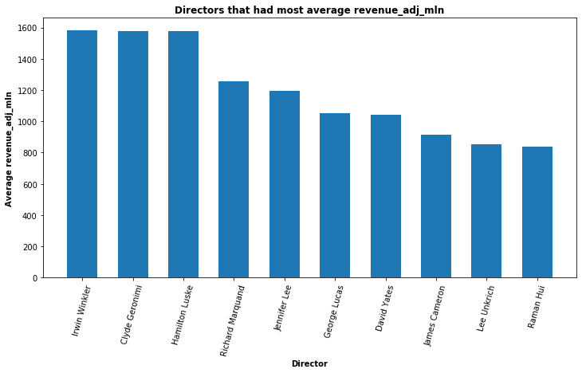

```python
df_director_non_zero[['revenue_adj_mln']] = df_director_non_zero.loc[:, ['revenue_adj_mln']].apply(pd.to_numeric)
x = df_director_non_zero[['director', 'revenue_adj_mln']].groupby('director').mean()['revenue_adj_mln'].sort_values(ascending=False).index[:10]
y = df_director_non_zero[['director', 'revenue_adj_mln']].groupby('director').mean()['revenue_adj_mln'].sort_values(ascending=False)[:10]
x_label = 'Director'
y_label = 'Average revenue_adj_mln'
title = 'Directors that had most average revenue_adj_mln'
bar_chart(x, y, x_label, y_label, title)
```

Irwin Winkler, Clyde Geronimi, Hamilton Luske, Richard Marquand and Jennifer Lee are top 5 most successful directors in terms of their movies' revenues.

And now we will calculate average return on investment for every director.

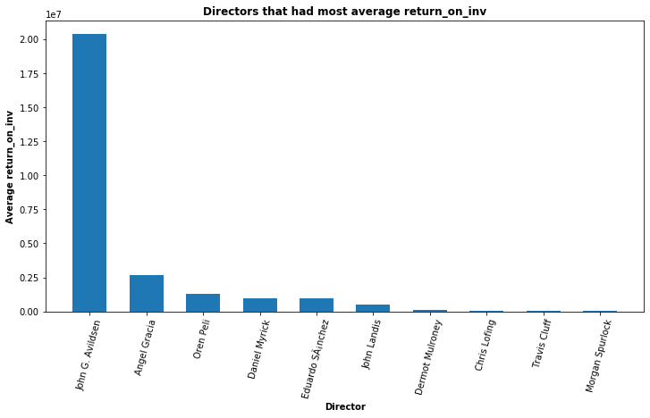

```python
df_director_non_zero[['return_on_inv']] = df_director_non_zero.loc[:, ['return_on_inv']].apply(pd.to_numeric)
x = df_director_non_zero[['director', 'return_on_inv']].groupby('director').mean()['return_on_inv'].sort_values(ascending=False).index[:10]
y = df_director_non_zero[['director', 'return_on_inv']].groupby('director').mean()['return_on_inv'].sort_values(ascending=False)[:10]
x_label = 'Director'
y_label = 'Average return_on_inv'
title = 'Directors that had most average return_on_inv'
bar_chart(x, y, x_label, y_label, title)
```

John G.Avildsen is paricularly the most successful director in terms of average return on investment for their movies.

#### For actors

For film actors, let's create a dataframe without nulls and pipes:

```python
df_actor = df.dropna(subset=['cast'])
df_actor.reset_index(drop=True, inplace=True)
df_actor.loc[:,'cast'] = df_actor['cast'].str.replace("|", ";")
pipe_count_actor = df_actor['cast'].str.count(';')
df_actor2 = pd.DataFrame(np.repeat(df_actor.values, list(pipe_count_actor+1), axis=0))
df_actor2.columns = df_actor.columns
df_actor2['cast'] = list(np.concatenate(df_actor['cast'].str.split(';')))
df_actor2.shape
```

```
(52573, 21)
```

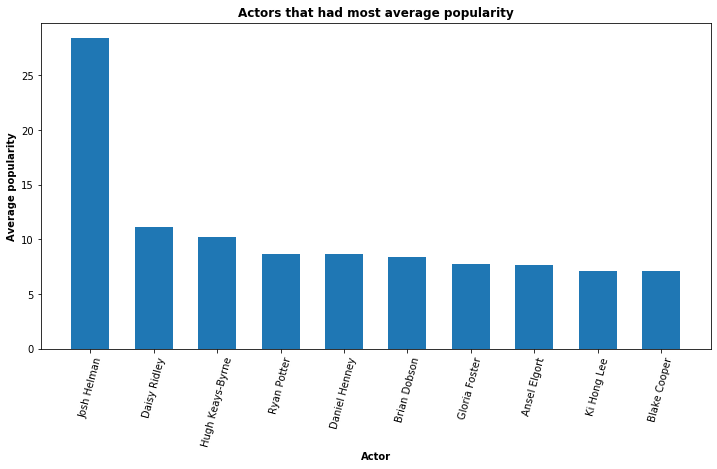

```python
df_actor2[['popularity']] = df_actor2.loc[:, ['popularity']].apply(pd.to_numeric)
x = df_actor2[['cast', 'popularity']].groupby('cast').mean()['popularity'].sort_values(ascending=False).index[:10]
y = df_actor2[['cast', 'popularity']].groupby('cast').mean()['popularity'].sort_values(ascending=False)[:10]
x_label = 'Actor'
y_label = 'Average popularity'
title = 'Actors that had most average popularity'
bar_chart(x, y, x_label, y_label, title)
```

Josh Helman, Daisy Ridley, Hugh Keays-Byrne, and Ryan Potter are top 4 actors in terms of average popularity of movies they cast.

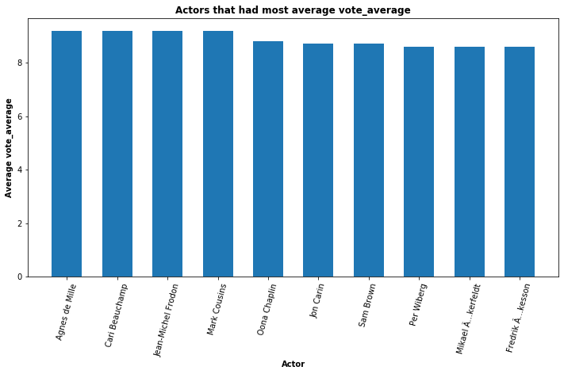

```python
df_actor2[['vote_average']] = df_actor2.loc[:, ['vote_average']].apply(pd.to_numeric)
x = df_actor2[['cast', 'vote_average']].groupby('cast').mean()['vote_average'].sort_values(ascending=False).index[:10]
y = df_actor2[['cast', 'vote_average']].groupby('cast').mean()['vote_average'].sort_values(ascending=False)[:10]
x_label = 'Actor'
y_label = 'Average vote_average'
title = 'Actors that had most average vote_average'
bar_chart(x, y, x_label, y_label, title)
```

All the top 10 actors with highest vote_average had almost the same vote_average with each other.

For return on investment we should calculate (revenue_adj_mln - budget_adj_mln)/budget_adj_mln. If budget_adj_mln = 0, we receive an error message. So let's drop zero values in both 'budget_adj_mln' and 'revenue_adj_mln' in order to avoid distortion, and create 'return_on_inv' column

```python
df_actor_non_zero = df_actor2[(df_actor2['budget_adj_mln'] != 0) & (df_actor2['revenue_adj_mln'] != 0)]
df_actor_non_zero['return_on_inv'] = (df_actor_non_zero['revenue_adj_mln'] - df_actor_non_zero['budget_adj_mln'])*100/df_actor_non_zero['budget_adj_mln']
```

For return on investment we should calculate (revenue_adj_mln - budget_adj_mln)/budget_adj_mln. If budget_adj_mln = 0, we receive an error message. So let's drop zero values in both 'budget_adj_mln' and 'revenue_adj_mln' in order to avoid distortion, and create 'return_on_inv' column

And now we will calculate average revenue_adj_mln for every actor.

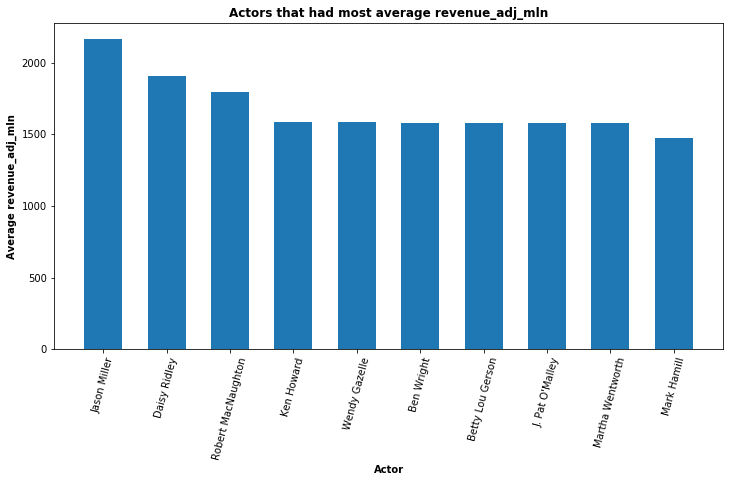

```python
df_actor_non_zero[['revenue_adj_mln']] = df_actor_non_zero.loc[:, ['revenue_adj_mln']].apply(pd.to_numeric)
x = df_actor_non_zero[['cast', 'revenue_adj_mln']].groupby('cast').mean()['revenue_adj_mln'].sort_values(ascending=False).index[:10]
y = df_actor_non_zero[['cast', 'revenue_adj_mln']].groupby('cast').mean()['revenue_adj_mln'].sort_values(ascending=False)[:10]
x_label = 'Actor'
y_label = 'Average revenue_adj_mln'
title = 'Actors that had most average revenue_adj_mln'
bar_chart(x, y, x_label, y_label, title)
```

Jason Miller, Daisy Ridley and Robert MacNaughton are top 3 actors in terms of average revenues of movies they cast.

And now we will calculate average return on investment for every actor.

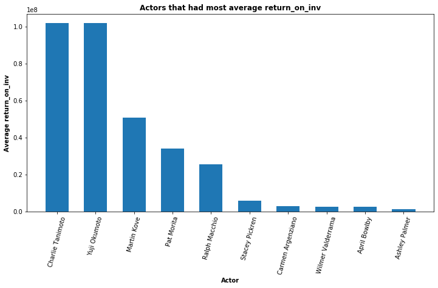

```python
df_actor_non_zero[['return_on_inv']] = df_actor_non_zero.loc[:, ['return_on_inv']].apply(pd.to_numeric)
x = df_actor_non_zero[['cast', 'return_on_inv']].groupby('cast').mean()['return_on_inv'].sort_values(ascending=False).index[:10]
y = df_actor_non_zero[['cast', 'return_on_inv']].groupby('cast').mean()['return_on_inv'].sort_values(ascending=False)[:10]
x_label = 'Actor'
y_label = 'Average return_on_inv'
title = 'Actors that had most average return_on_inv'
bar_chart(x, y, x_label, y_label, title)
```

Charlie Tanimoto, Yuji Okumoto and Martin Kove are top 3 actors in terms of average return of investment on movies they cast.

### Research Question 6 (Does the budget of a movie really play a role in its profitability?)

For answering this question, let's add a 'profit_adj_mln' column to the dataframe:

```python
df['profit_adj_mln'] = df['revenue_adj_mln'] - df['budget_adj_mln']
df.head(1)
```

|  | id | imdb_id | popularity | budget_mln | revenue_mln | original_title | cast | homepage | director | tagline | ... | runtime | genres | production_companies | release_date | vote_count | vote_average | release_year | budget_adj_mln | revenue_adj_mln | profit_adj_mln |
| --- | --- | --- | --- | --- | --- | --- | --- | --- | --- | --- | --- | --- | --- | --- | --- | --- | --- | --- | --- | --- | --- |
| 0 | 135397 | tt0369610 | 32.985763 | 150.0 | 1513.52881 | Jurassic World | Chris Pratt\|Bryce Dallas Howard\|Irrfan Khan\|Vi... | http://www.jurassicworld.com/ | Colin Trevorrow | The park is open. | ... | 124 | Action\|Adventure\|Science Fiction\|Thriller | Universal Studios\|Amblin Entertainment\|Legenda... | 6/9/15 | 5562 | 6.5 | 2015 | 137.999939 | 1392.445893 | 1254.445953 |

1 rows × 22 columns

Let's create a scatterplot to see the correlation between 'budget_adj_mln' and 'profit_adj_mln'

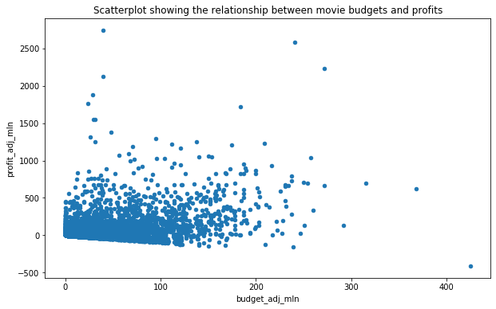

```python
df.plot(kind='scatter', x='budget_adj_mln', y='profit_adj_mln', figsize=(10, 6), title='Scatterplot showing the relationship between movie budgets and profits', legend=True)
```

```python
df.corr().loc['budget_adj_mln', 'profit_adj_mln']
```

```
0.47290061862598537
```

## Conclusions

#### For question 1.

"Adventure", "animation" and "fantasy" movies have been most popular throughout the years.

#### For question 3.

Movies that have higher revenues have higher budgets, popularity, average votes and runtime than movies that have lower revenues.

#### For question 4.

For genres:

- "Adventure", "Science Fiction", "Fantasy" and "Action" are top 4 genres in terms of average popularity ratings of movies.
- ""Documentary", "Music", "History" and "Animation" are top 4 genres in terms of average votes of movies.
- "Animation", "Adventure", "Fantasy" and "Family" are top 4 genres in terms of average revenues (inflation adjusted) of movies.
- "Family", "Romance", "Adventure" and "Action" are top 4 genres in terms of average ROI (return on investment) of movies.

For keywords:

- "Velociraptor", "nihilism", "woman with gun" and "scene during end credits" are top 4 keywords of films in terms of their average popularity.
- "Hindi cinema", "nouvelle vague", "cinema nove" and "russian cinema" are top 4 keywords in terms of movies' vote_average.
- "Space war", "hermit", "lightsaber" and "iceberg" are top 4 keywords in terms of average revenues of films.
- "Okinawa", "revanche" and "self esteem" are top vivid keywords in terms of movies' average return on investment.

#### For question 5.

For directors:

- Colin Trevorrow, David Leitch, Chad Stahelski and are top 3 successful film directors in terms of average popularity of their movies.
- All the top 10 directors with highest vote_average had almost the same vote_average with each other, except for Mark Cousins having slightly more.
- Irwin Winkler, Clyde Geronimi, Hamilton Luske, Richard Marquand and Jennifer Lee are top 5 most successful directors in terms of their movies' revenues.
- John G.Avildsen is paricularly the most successful director in terms of average return on investment for their movies.

For actors:

- Josh Helman, Daisy Ridley, Hugh Keays-Byrne, and Ryan Potter are top 4 actors in terms of average popularity of movies they cast.
- All the top 10 actors with highest vote_average had almost the same vote_average with each other.
- Jason Miller, Daisy Ridley and Robert MacNaughton are top 3 actors in terms of average revenues of movies they cast.
- Charlie Tanimoto, Yuji Okumoto and Martin Kove are top 3 actors in terms of average return of investment on movies they cast.